# SubCellBarCode: Integrated workflow for robust classification and visualization of spatial proteome

Taner Arslan, Lukas Orre, Mattias Vesterlund, Yanbo Pan and Janne Lehtio

Karolinska Institute, Stockholm, Sweden

2019-02-26

#### Abstract

In the SubCellBarCode project, mass spectrometry (MS) based proteomics was used for proteome-wide mapping of protein subcellular localization (Orre et al. 2019, Molecular Cell). Subcellular fractionation and MS-based quantification can be reproduced following the methods described in Orre et al. Here, the SubCellBarCode R package offers tools to reproduce the underlying bioinformatics pipeline for robust classification and visualization of proteins into corresponding subcellular localizations. Moreover, the R-package can be used for differential localization analysis to investigate e.g. treatment induced protein relocalization, condition dependent localization or cell type specific localization.

#### Package

SubCellBarCode 0.1.0

# 1 Installation of the package

`SubCellBarCode` can be installed from github using `devtools` package:

```r
install.packages("devtools")
library(devtools)
install_github("TanerArslan/SubCellBarCode-R-Package")
```

# 2 Load the package

```r
library(SubCellBarCode)
```

# 3 Data preparation and classification

## 3.1 Example Data

As example data we here provide the publicly available HCC827 (human lung adenocarcinoma cell line) TMT10plex labelled proteomics dataset (*Orre et al.* 2019, Molecular Cell). The `data.frame` consists of 10480 proteins as rows (rownames must be gene centric protein ids) and 5 fractions with duplicates as columns (replicates should be named “.A.” and “.B.”, repectively).

```r
head(hcc827Ctrl)
```

```
##        FS1.A.HCC827 FS1.B.HCC827 FS2.A.HCC827 FS2.B.HCC827 FP1.A.HCC827
## A2M          6.6567       4.8238       0.8265       0.8279       0.4475
## A2ML1        1.2876       1.0878       0.6390       0.7828       0.8760
## A4GALT       0.4711       0.4106       0.2742       0.2689       0.8389
## AAAS         0.5108       0.4514       0.4470       0.4752       1.6576
## AACS         4.5593       4.4522       1.5694       1.6417       0.5294
## AAED1        0.8170       0.7031       0.5415       0.5902       0.9429
##        FP1.B.HCC827 FP2.A.HCC827 FP2.B.HCC827 FP3.A.HCC827 FP3.B.HCC827
## A2M          0.5803       0.6414       0.6014       0.6497       0.6216
## A2ML1        0.9138       2.6957       1.3606       0.7715       0.7859
## A4GALT       0.8043       1.9637       1.8340       1.6739       1.6848
## AAAS         1.7316       1.3773       1.4688       1.0071       1.0457
## AACS         0.5197       0.5109       0.5232       0.4197       0.4243
## AAED1        0.9505       1.9035       1.8475       1.1060       1.1636
```

## 3.2 Marker Proteins

The classification of protein localisation using the SubCellBarCode method is dependent on 3365 marker proteins as defined in Orre et al. The markerProteins `data.frame` contains protein names (gene symbol), associated subcellular localization (compartment), color code for the compartment and the median normalized fractionation profile (log2) based on five different human cell lines (NCI-H322, HCC827, MCF7, A431and U251) here called the “5CL marker profile”.

```r
head(markerProteins)
```

```
##          Proteins Compartments       Cyto        Nsol       NucI        Horg
## AAAS         AAAS           S4 -1.0033518 -1.15489468  0.9303367  0.48554266
## AACS         AACS           C4  2.1716569  0.13246046 -1.0394634 -1.13265585
## AAK1         AAK1           C3  1.8556445  0.10015281 -0.6605511 -0.36985132
## AARS         AARS           C4  2.1012831  0.05855811 -1.0439250 -1.08451971
## AASDHPPT AASDHPPT           C5  1.7065897  0.51507061 -0.7196594 -0.65267201
## AATF         AATF           N3 -0.8922053 -1.10101864  1.2202070  0.05316807
##                Lorg       Colour
## AAAS      0.1618329      tomato2
## AACS     -1.3217619 deepskyblue2
## AAK1     -0.6741959         cyan
## AARS     -1.2180979 deepskyblue2
## AASDHPPT -1.0059841   turquoise3
## AATF      0.1898676       grey50
```

## 3.3 Load and normalize data

Input `data.frame` is checked with *“NA”* values and for the correct format. If there is any *“NA”* value, corresponding row is deleted. Then, data frame is `log2` transformmed.

```r
df <- loadData(protein.data = hcc827Ctrl)
```

```r
print(dim(df))
```

```
## [1] 10480    10
```

```r
head(df)
```

```
##        FS1.A.HCC827 FS1.B.HCC827 FS2.A.HCC827 FS2.B.HCC827 FP1.A.HCC827
## A2M       2.7348072    2.2701701   -0.2749133   -0.2724716  -1.16004041
## A2ML1     0.3646845    0.1214133   -0.6461122   -0.3532843  -0.19099723
## A4GALT   -1.0858948   -1.2841945   -1.8666995   -1.8948583  -0.25342925
## AAAS     -0.9691696   -1.1475217   -1.1616533   -1.0733933   0.72909591
## AACS      2.1888123    2.1545184    0.6502131    0.7151905  -0.91756990
## AAED1    -0.2915920   -0.5081982   -0.8849668   -0.7607242  -0.08482332
##        FP1.B.HCC827 FP2.A.HCC827 FP2.B.HCC827 FP3.A.HCC827 FP3.B.HCC827
## A2M     -0.78512917   -0.6407037   -0.7336032  -0.62215439  -0.68594159
## A2ML1   -0.13004965    1.4306600    0.4442430  -0.37426194  -0.34758234
## A4GALT  -0.31419437    0.9735745    0.8749936   0.74321334   0.75257734
## AAAS     0.79210571    0.4618428    0.5546380   0.01020694   0.06446902
## AACS    -0.94424904   -0.9688872   -0.9345656  -1.25256963  -1.23684342
## AAED1   -0.07324147    0.9286546    0.8855744   0.14535139   0.21859520
```

## 3.4 Calculate covered marker proteins

The overlap between *marker proteins (3365)* and *input data.frame* is calculated and visualized for each compartment by a bar plot.

*Note that we recommend at least 20% coverage of marker proteins for each compartment. If certain compartments are underrrepresented we recommend you to perform the cell fractionation again. If all compartments are low in coverage we recommend increasing the analytical depth of the MS-analysis.*

```r
c.prots <- calculateCoveredProtein(proteinIDs = rownames(df),
                        markerproteins = markerProteins[,1])
```

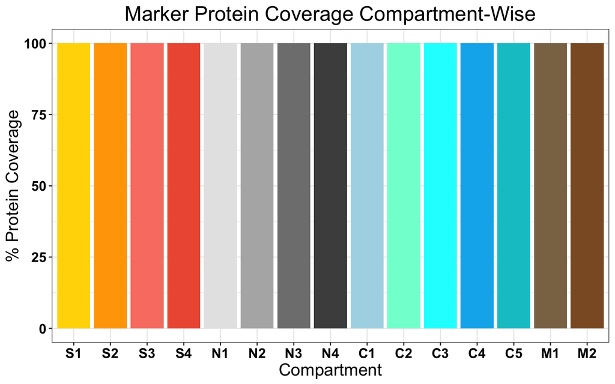

```
## Overall Coverage of marker proteins : 1
```

## 3.5 Quality control of the marker proteins

To avoid reduced classification accuracy, marker proteins with noisy quantificationand marker proteins that are not representative of their associated compartment (e.g.due to cell type specific localization) are filtered out by a two-step quality control.

1. Marker proteins with pearson correlations less than 0.8 between *A* and *B* duplicates for each cell line were filtered out (Figure A).
2. Pairwise correlations between 5CL marker profile and input data for each protein (A and B replicate experiments separately) were calculated using both Pearson and Spearman correlation. The lowest value for each method were then used for filtering with cut-offs set to 0.8 and 0.6 respectively, to exclude non-representative marker proteins (Figure B).

```r
r.markers <- markerQualityControl(coveredProteins = c.prots, protein.data = df)
```

```
## Number of removed replicate-wise proteins: 0
```

```
## Number of removed sample-wise proteins: 1
```

```
## Number of total removed marker proteins: 1
```

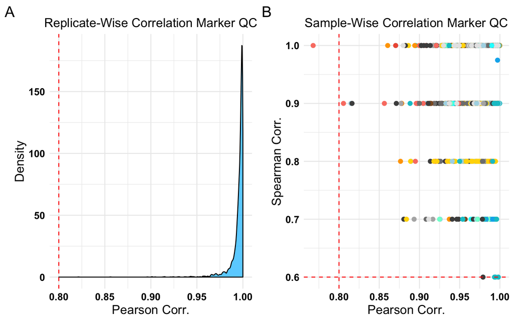

```r
r.markers[1:5]
```

```
## [1] "AAAS"     "AACS"     "AAK1"     "AARS"     "AASDHPPT"
```

**Optional step:** After removing non-marker proteins, you can re-calculate and visualize the final coverage of the marker proteins.

```r
# uncomment the function when running
# f.prots <- calculateCoveredProtein(r.markers, markerProteins[,1])
```

## 3.6 Visualization of marker proteins in t-SNE map

The spatial distribution of the marker proteins is vizualized in t-SNE map. This plot will be informative for the quality control of the generated data as it offers evaluation of the spatial distribution and separation of marker proteins.

```r
#Default parameters
#Output dimensionality
#dims = 3
#Speed/accuracy trade-off (increase for less accuracy)
#theta = c(0.1, 0.2, 0.3, 0.4, 0.5)
#Perplexity parameter
#perplexity = c(5, 10, 20, 30, 40, 50, 60)
```

Information about the different t-SNE parameters that can be modified by the user is available by typing `?Rtsne` in the console.  
Although the applications of t-SNE is widespread in the field of machine learning, it can be misleading if it is not well optimized. Therefore, we optimize t-SNE map by grid search, a process that can take some time

```
## Optimization process started. This may take some time!
```

```
## Optimization was performed.
```

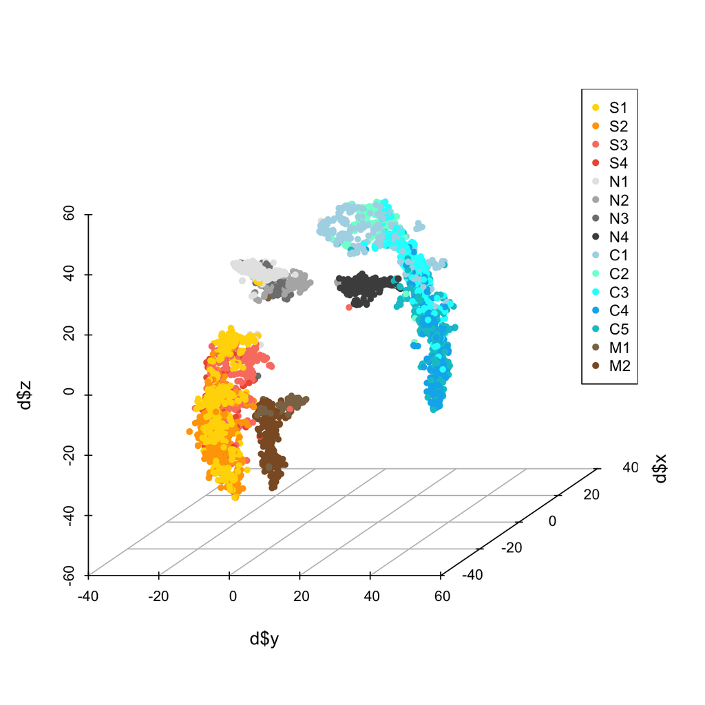

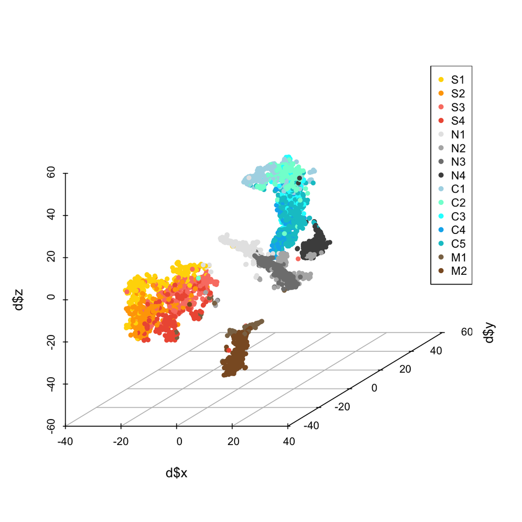

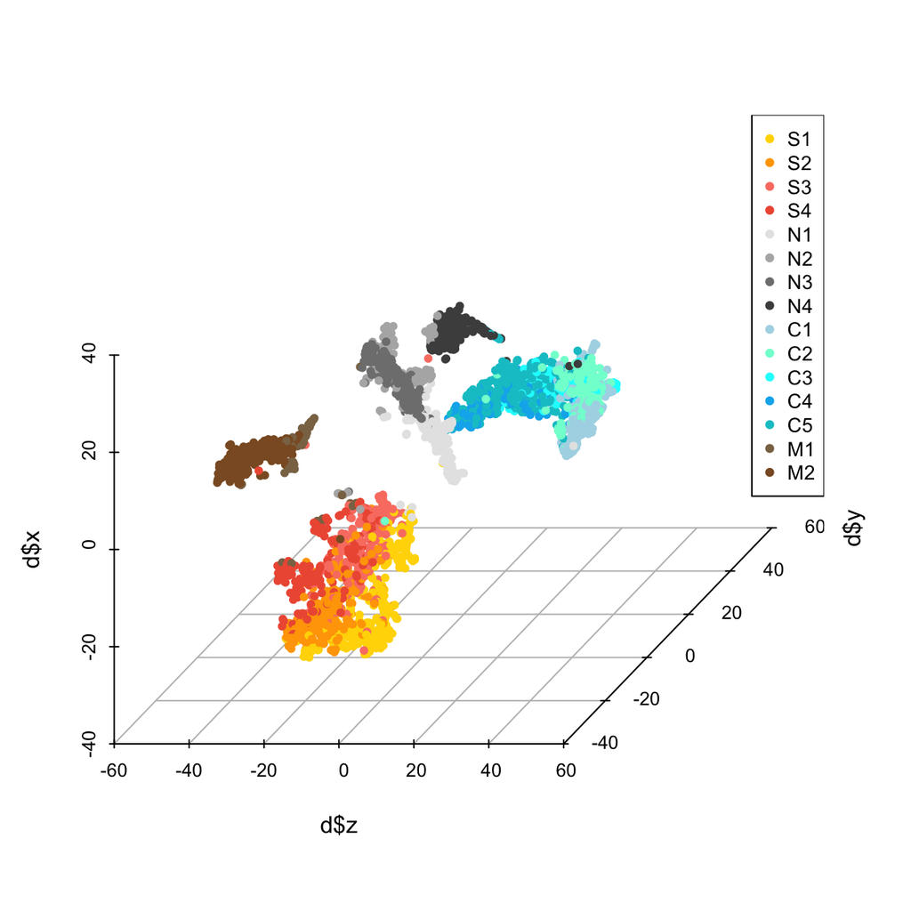

```r
set.seed(6)
tsne.map <- tsneVisualization(protein.data = df,
                    markerProteins = r.markers,
                    dims = 3,
                    theta = c(0.1, 0.2, 0.3, 0.4, 0.5),
                    perplexity = c(5, 10, 20, 30, 40, 50, 60))
```

We recommend 3D vizualisation by setting `dims = 3`, for optimal evaluation of marker protein cluster separation and data modularity. You can also visualize the marker proteins in 2 dimensional space by setting `dims = 2`, although reducing the dimensionality results in loss of information and underestimation of data resolution.

```
## Optimization process started. This may take some time!
```

```
## Optimization was performed.
```

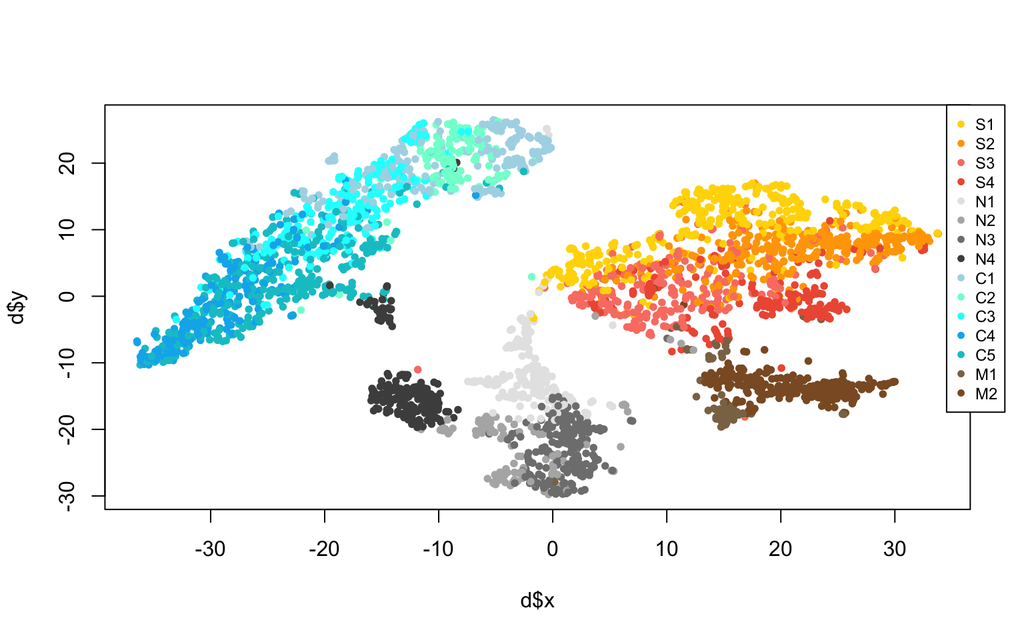

```r
set.seed(9)
tsne.map2 <- tsneVisualization(protein.data = df,
                    markerProteins = r.markers,
                    dims = 2,
                    theta = c(0.1, 0.2, 0.3, 0.4, 0.5),
                    perplexity = c(5, 10, 20, 30, 40, 50, 60))
```

## 3.7 Build model and classify proteins

For replicate *A* and *B* separately, marker proteins are used for training a Support Vector Machine (SVM) classifier with a Gaussian radial basis function kernel algorithm. After tuning the parameters, the SVM model predicts (classifies) the subcellular localization for all proteins in the input data with corresponding probabilities for *A* and *B* replicate classification.

```r
set.seed(2)
cls <- svmClassification(markerProteins = r.markers,
                                    protein.data = df,
                                    markerprot.df = markerProteins)
```

```r
# testing data predictions for replicate A and B
test.A <- cls[[1]]$svm.test.prob.out
test.B <- cls[[2]]$svm.test.prob.out
head(test.A)
```

```
##         Observation svm.pred           S1           S2           S3
## AAK1             C3       C3 0.0017873910 0.0015211439 0.0013573130
## ABCB8            M2       M2 0.0002218549 0.0001988545 0.0002775492
## ABCC1            S4       S4 0.0103896008 0.0138802330 0.0202959445
## ABCD1            S3       S1 0.5183630415 0.0320310081 0.4247733069
## ABCD3            S2       S2 0.1594084542 0.7271693374 0.0772877530
## ABHD17C          S1       S1 0.9845971132 0.0050058927 0.0010690278
##                   S4           N1           N2           N3           N4
## AAK1    0.0010347056 0.0017808169 0.0013986986 0.0016866999 0.0015969312
## ABCB8   0.0003045749 0.0005192678 0.0003333258 0.0004586015 0.0004806812
## ABCC1   0.3837750142 0.0131447278 0.0382193649 0.0540841276 0.0135158108
## ABCD1   0.0040394310 0.0003689942 0.0002815237 0.0004088372 0.0007985691
## ABCD3   0.0185884684 0.0012135634 0.0011327673 0.0011310676 0.0016416864
## ABHD17C 0.0003951489 0.0012153730 0.0007322376 0.0012925140 0.0008380390
##                   C1           C2           C3           C4           C5
## AAK1    0.2889654069 0.0069691155 0.6244632986 0.0417464849 0.0232141128
## ABCB8   0.0005128780 0.0004803797 0.0003910250 0.0004442762 0.0005206065
## ABCC1   0.0086928853 0.0076391206 0.0048135149 0.0058970395 0.0080746441
## ABCD1   0.0005468668 0.0004526086 0.0005166201 0.0006703511 0.0007486949
## ABCD3   0.0012045029 0.0012269608 0.0008808747 0.0010965866 0.0013250038
## ABHD17C 0.0004925607 0.0006184508 0.0004515211 0.0005650584 0.0006448930
##                   M1          M2
## AAK1    0.0012113794 0.001266502
## ABCB8   0.0261586218 0.968697503
## ABCC1   0.1692315113 0.248346461
## ABCD1   0.0011083640 0.014891783
## ABCD3   0.0015740290 0.005118944
## ABHD17C 0.0007000878 0.001382082
```

```r
# all predictions for replicate A and B
all.A <- cls[[1]]$all.prot.pred
all.B <- cls[[2]]$all.prot.pred
```

### 3.7.1 Estimate classification thresholds for compartment level

Classification probabilities close to 1 indicate high confidence predictions, whereas probabilities close to 0 indicate low confidence predictions. To increase the overal prediction accuracy and to filter out poor predictions, one criterion and two cut-offs are defined.

1. The criterion is the consensus of preliminary predictions between biological duplicates. Proteins are kept in the analysis, if there is an agreement between biological duplicates. Subsequently, prediction probabilities from the two duplicates are averaged for each protein.
2. Cut-off is (precision - based) set when precision reach 0.9 in the test data.
3. Cut-off is (recall - based) set as the probability of the lowest true positive in the test data.

```r
t.c.df <- computeThresholdCompartment(test.repA = test.A, test.repB = test.B)
```

```r
head(t.c.df)
```

```
##   Compartment PrecisionBasedThreshold RecallBasedThreshold OptedThreshold
## 1          S1                       0                0.522          0.522
## 2          S2                   0.811                0.451          0.811
## 3          S3                   0.815                0.326          0.815
## 4          S4                   0.692                0.388          0.692
## 5          N1                   0.765                0.378          0.765
## 6          N2                   0.316                0.582          0.582
```

### 3.7.2 Apply threshold to compartment level classifications

The determined thresholds for the compartment levels are applied to all classifications.

```r
c.cls.df <- applyThresholdCompartment(all.repA = all.A, all.repB = all.B,
                                    threshold.df = t.c.df)
```

```r
head(c.cls.df)
```

```
##        Proteins svm.pred        S1          S2          S3           S4
## A4GALT   A4GALT       S1 0.9703375 0.010911487 0.004652716 0.0009960136
## ABCA12   ABCA12       S1 0.8949947 0.089798406 0.006246638 0.0005183263
## ABCA2     ABCA2       S1 0.5452503 0.079986383 0.360583580 0.0073093009
## ABCA3     ABCA3       S1 0.8973031 0.073901830 0.024712743 0.0003909560
## ABCB6     ABCB6       S1 0.9880791 0.006072473 0.003726922 0.0000655145
## ABCB9     ABCB9       S1 0.9347789 0.027327501 0.035154848 0.0002742451
##                  N1           N2           N3           N4           C1
## A4GALT 2.190984e-03 0.0012642366 0.0012590352 0.0013702913 0.0012282651
## ABCA12 2.196335e-03 0.0008449108 0.0007333858 0.0007108248 0.0006621498
## ABCA2  7.632375e-04 0.0004960978 0.0004900731 0.0005373247 0.0004261678
## ABCA3  3.910144e-04 0.0003074924 0.0002832500 0.0003408193 0.0003640615
## ABCB6  9.618363e-05 0.0001172517 0.0001455285 0.0002243957 0.0001601079
## ABCB9  1.738805e-04 0.0001554491 0.0001628670 0.0002426728 0.0001988070
##                  C2           C3           C4           C5           M1
## A4GALT 0.0011503398 0.0005841114 0.0006961554 0.0009199930 0.0013238336
## ABCA12 0.0007160293 0.0004035622 0.0004873552 0.0005913370 0.0005752972
## ABCA2  0.0003616579 0.0003695448 0.0005068573 0.0005897231 0.0007628135
## ABCA3  0.0003459700 0.0003164937 0.0003837885 0.0004219372 0.0002504618
## ABCB6  0.0001544553 0.0002192852 0.0002947701 0.0003104006 0.0001612595
## ABCB9  0.0001741175 0.0002422247 0.0003099141 0.0003256765 0.0002043140
##                  M2
## A4GALT 0.0011149960
## ABCA12 0.0005207827
## ABCA2  0.0015669369
## ABCA3  0.0002861040
## ABCB6  0.0001723165
## ABCB9  0.0002745980
```

### 3.7.3 Estimate classification thresholds for neighborhood level

Compartment level classification probabilities are summed to neighborhood probabilities and thresholds for neighborhood analysis are estimated as described above for compartment level analysis except precision based cut-off is set to 0.95.

```r
t.n.df <- computeThresholdNeighborhood(test.repA = test.A, test.repB = test.B)
```

```r
head(t.n.df)
```

```
##   Neighborhood PrecisionBasedThreshold RecallBasedThreshold OptedThreshold
## 1    Secretory                       0                0.476          0.476
## 2      Nuclear                       0                0.688          0.688
## 3      Cytosol                       0                0.824          0.824
## 4 Mitochondria                       0                0.677          0.677
```

### 3.7.4 Apply threshold to neighborhood level classifications

The determined thresholds for the neighborhood levels are applied to all classifications.

```r
n.cls.df <- applyThresholdNeighborhood(all.repA = all.A, all.repB = all.B,
                                    threshold.df = t.n.df)
```

```r
head(n.cls.df)
```

```
##        Proteins svm.pred.all Secretory      Nuclear     Cytosol Mitochondria
## A4GALT   A4GALT    Secretory 0.9868978 0.0060845468 0.004578865 0.0024388296
## ABCA12   ABCA12    Secretory 0.9915580 0.0044854566 0.002860434 0.0010960799
## ABCA2     ABCA2    Secretory 0.9931296 0.0022867332 0.002253951 0.0023297503
## ABCA3     ABCA3    Secretory 0.9963086 0.0013225761 0.001832251 0.0005365658
## ABCB6     ABCB6    Secretory 0.9979440 0.0005833595 0.001139019 0.0003335760
## ABCB9     ABCB9    Secretory 0.9975355 0.0007348694 0.001250740 0.0004789120
```

### 3.7.5 Merge compartment and neighborhood classification

Individual classifications (compartment and neighborhood) are merged into one data frame.

```r
cls.df <- mergeCls(compartmentCls = c.cls.df, neighborhoodCls = n.cls.df)
```

```r
head(cls.df)
```

```
##        Protein NeighborhoodCls CompartmentCls   Secretory     Nuclear
## A2M        A2M    Unclassified   Unclassified 0.070755393 0.129452696
## A4GALT  A4GALT       Secretory             S1 0.986897759 0.006084547
## AACS      AACS         Cytosol   Unclassified 0.003620868 0.005404611
## AAED1    AAED1       Secretory   Unclassified 0.846696281 0.022548342
## AAK1      AAK1         Cytosol   Unclassified 0.004599211 0.005178895
## AAMDC    AAMDC         Cytosol   Unclassified 0.003793849 0.004801656
##            Cytosol Mitochondria          S1           S2           S3
## A2M    0.777384272  0.022407640 0.030856654 0.0202810543 0.0122044086
## A4GALT 0.004578865  0.002438830 0.970337542 0.0109114871 0.0046527162
## AACS   0.989459683  0.001514838 0.001139552 0.0009057548 0.0008908736
## AAED1  0.024640451  0.106114925 0.096421936 0.0811698236 0.6277185624
## AAK1   0.988248944  0.001972950 0.001413062 0.0011698646 0.0011249057
## AAMDC  0.989816295  0.001588200 0.001181255 0.0009436714 0.0009425130
##                  S4          N1           N2          N3          N4
## A2M    0.0074132760 0.029124052 0.0137219857 0.024514850 0.062091808
## A4GALT 0.0009960136 0.002190984 0.0012642366 0.001259035 0.001370291
## AACS   0.0006846877 0.001159263 0.0008667271 0.001066341 0.002312280
## AAED1  0.0413859586 0.005705259 0.0051400144 0.005437850 0.006265219
## AAK1   0.0008913784 0.001413150 0.0011426825 0.001369215 0.001253847
## AAMDC  0.0007264098 0.001186694 0.0009000311 0.001096717 0.001618215
##                 C1          C2           C3           C4          C5
## A2M    0.081087729 0.026359922 0.0576453504 0.4637935466 0.148497724
## A4GALT 0.001228265 0.001150340 0.0005841114 0.0006961554 0.000919993
## AACS   0.002427278 0.003186406 0.0373133564 0.7090957806 0.237436862
## AAED1  0.005711654 0.006690323 0.0033633934 0.0038348407 0.005040240
## AAK1   0.291279449 0.010457648 0.6218935904 0.0341139398 0.030504316
## AAMDC  0.003633702 0.002103808 0.0534055479 0.6573558790 0.273317358
##                  M1           M2
## A2M    0.0098346873 0.0125729523
## A4GALT 0.0013238336 0.0011149960
## AACS   0.0007571315 0.0007577065
## AAED1  0.0076457898 0.0984691355
## AAK1   0.0009885050 0.0009844450
## AAMDC  0.0007951010 0.0007930994
```

# 4 Vizualization of the protein subcellular localization

## 4.1 SubCellBarCode plot

You can query one protein at a time to plot barcode of the protein of the interest.

`PSM` (Peptide-spectra-matching) count table is required for the plotting SubCellBarCode. It is in `data.frame` format;

```r
head(hcc827CtrlPSMCount)
```

```
##        Protein PSMs.for.quant
## A2M        A2M             11
## A2ML1    A2ML1              2
## A4GALT  A4GALT              1
## AAAS      AAAS             33
## AACS      AACS             60
## AAED1    AAED1              9
```

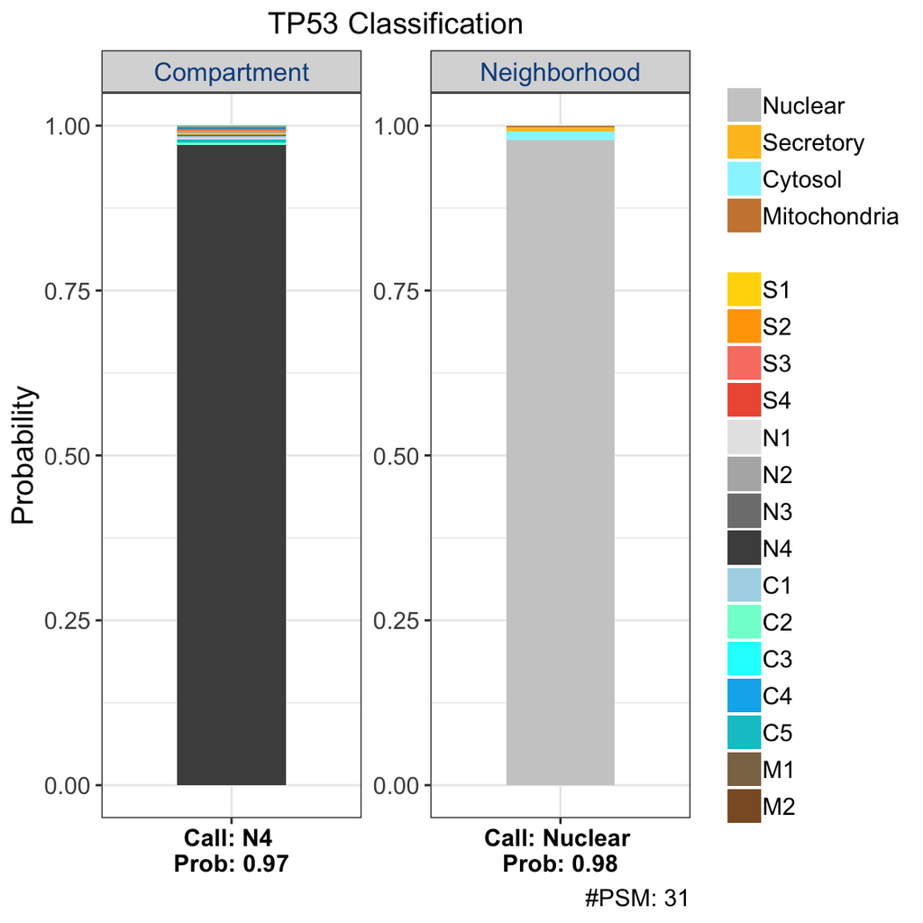

```r
plotBarcode(sampleClassification = cls.df, protein = "TP53",
            s1PSM = hcc827CtrlPSMCount)
```

## 4.2 Co-localization plot

To evaluate localization and of multiple proteins at the same time, a vector of proteins (identified by gene symbols) can be prepared and used to create a barplot showing the distribution of classifications across compartments and neighborhoods. This analysis could be helpful when evaluating co-localization of proteins, protein complex formation and compartmentalized protein level regulation.

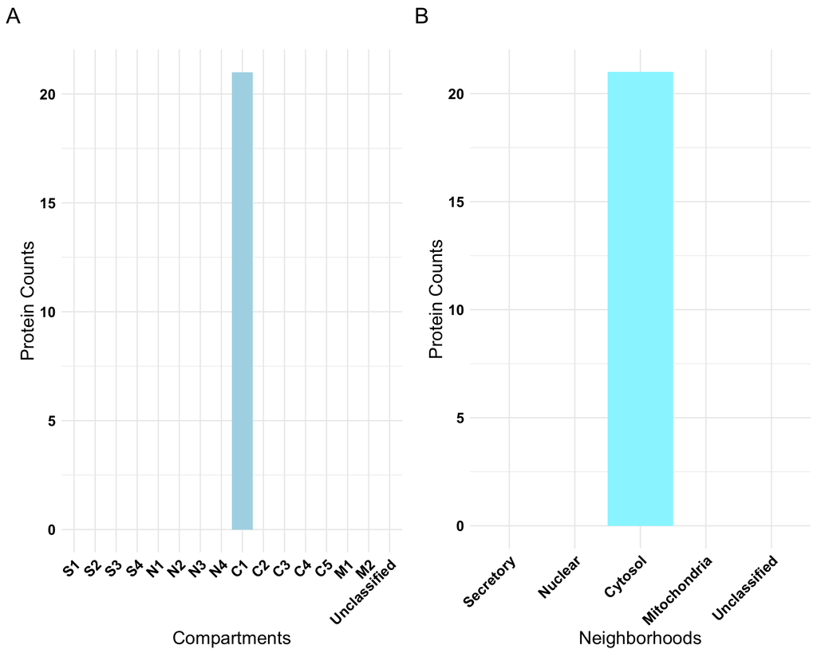

```r
# 26S proteasome complex (26s proteasome regulatory complex)
proteasome26s <- c("PSMA7", "PSMC3", "PSMB1", "PSMA1", "PSMA3",
"PSMA4", "PSMA5", "PSMB4", "PSMB6", "PSMB5", "PSMC2","PSMC4","PSMB3",
"PSMB2", "PSMD4","PSMA6","PSMC1","PSMC5","PSMC6","PSMB7","PSMD13")

plotMultipleProtein(sampleClassification = cls.df, proteinList = proteasome26s)
```

# 5 Differential localization analysis

Regulation of protein localization is a the key process in cellular signalling. The `SubCellBarCode` method can be used for differential localization analysis given two conditions such as control vs treatment, cancer cell *vs* normal cell, cell state A *vs* cell state B, *etc*. As example, we compared untreated and gefitinib (EGFR inhibitor) treated HCC827 cells (for details, see Orre et al.).

## 5.1 Identify differentially localizing proteins

Neighborhood classifications for condition 1 (untreated) and condition 2 (gefitinib) is first done separately, and classifications for overlapping proteins are then vizualized by a sankey plot.  
*The HCC827 gefitinib cell lines classification was embedded into the package for example analysis.*

```r
head(hcc827GEFClass)
```

```
##        Protein NeighborhoodCls CompartmentCls
## A2M        A2M         Cytosol   Unclassified
## A2ML1    A2ML1    Unclassified   Unclassified
## A4GALT  A4GALT       Secretory             S1
## AAAS      AAAS       Secretory             S4
## AACS      AACS         Cytosol   Unclassified
## AAED1    AAED1       Secretory   Unclassified
```

```r
sankeyPlot(sampleCls1 = cls.df, sampleCls2 = hcc827GEFClass)
```

```
## [[1]]
##          neigh.names id group
## 1    Cond1.Secretory  0     1
## 2      Cond1.Nuclear  1     2
## 3      Cond1.Cytosol  2     3
## 4 Cond1.Mitochondria  3     4
## 5    Cond2.Secretory  4     1
## 6      Cond2.Nuclear  5     2
## 7      Cond2.Cytosol  6     3
## 8 Cond2.Mitochondria  7     4
##
## [[2]]
##    source target value
## 1       0      4  2339
## 2       0      5    18
## 3       0      6    26
## 4       0      7    16
## 5       1      4    22
## 6       1      5  2159
## 7       1      6    35
## 8       2      4    49
## 9       2      5    34
## 10      2      6  3361
## 11      3      4    11
## 12      3      5     2
## 13      3      6     2
## 14      3      7   581
```

[interactive chart not shown]

## 5.2 Filter Candidates

As the differential localization analysis is an outlier analysis, it will include analytical noise. To filter out such noise, `PSM` (Peptide-spectra-matching) counts and fractionation profile correlation analysis (Pearson) was done to identify strong candidates. The PSM count format for the input have to be the same between the compared conditions;

```r
head(hcc827CtrlPSMCount)
```

```
##        Protein PSMs.for.quant
## A2M        A2M             11
## A2ML1    A2ML1              2
## A4GALT  A4GALT              1
## AAAS      AAAS             33
## AACS      AACS             60
## AAED1    AAED1              9
```

For each protein, the minimum PSM count between the two conditions is plotted against the fractionation profile (median) correlation between the two conditions. For proteins with different localizations between conditions, the fractionation profile differs and therefore we are expecting a low fractionation profile correlation. A standard setting for filtering of analytical noise in the differential localization analysis could be to demand a fractionation profile correlation below 0.8, and a minimum PSM count of at least 3.

```r
##parameters
#sampleCls1 = sample 1 classification output
#s1PSM = sample 2 PSM count
#s1Quant = Sample 1 Quantification data
#sampleCls2 = sample 2 classification output
#s2PSM = sample 2 classification output
#sample2Quant = Sample 2 Quantification data
```

```r
candidate.df <- candidateRelocatedProteins(sampleCls1 = cls.df,
                                s1PSM = hcc827CtrlPSMCount,
                                s1Quant = hcc827Ctrl,
                                sampleCls2 = hcc827GEFClass,
                                s2PSM = hcc827GefPSMCount,
                                s2Quant = hcc827GEF)
```

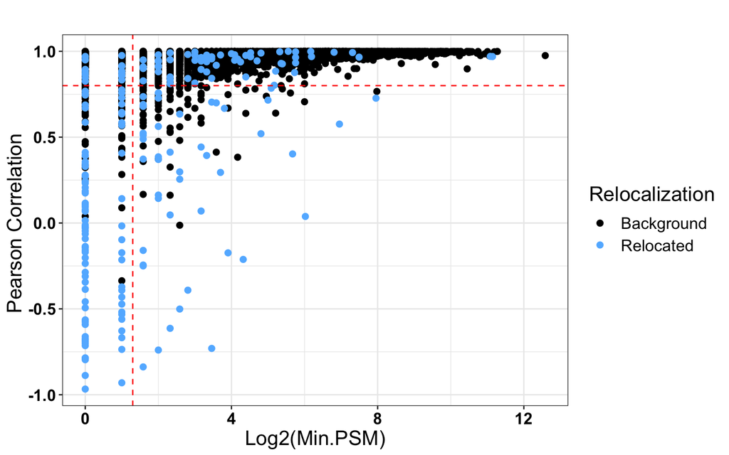

```r
print(dim(candidate.df))
```

```
## [1] 45  5
```

```r
head(candidate.df)
```

```
##        Protein       C.A       C.B Pearson.Corr Min.PSMs
## ACD        ACD   Cytosol   Nuclear    0.7274418        4
## AGAP2    AGAP2   Nuclear   Cytosol    0.4888424        3
## ANKEF1  ANKEF1   Cytosol Secretory    0.5230030        3
## ARRDC1  ARRDC1 Secretory   Cytosol    0.3931511       10
## BATF3    BATF3   Nuclear   Cytosol   -0.6132878        5
## CEP76    CEP76   Nuclear   Cytosol    0.7567105        4
```

Candidate subset of differentially localizing proteins can be annotated with names by setting `annotation = TRUE`, `min.psm` and `pearson.cor`

```r
candidate2.df <- candidateRelocatedProteins(sampleCls1 = cls.df,
                                s1PSM = hcc827CtrlPSMCount,
                                s1Quant = hcc827Ctrl,
                                sampleCls2 = hcc827GEFClass,
                                s2PSM = hcc827GefPSMCount,
                                s2Quant = hcc827GEF,
                                annotation = TRUE,
                                min.psm = 10,
                                pearson.cor = 0.1)
```

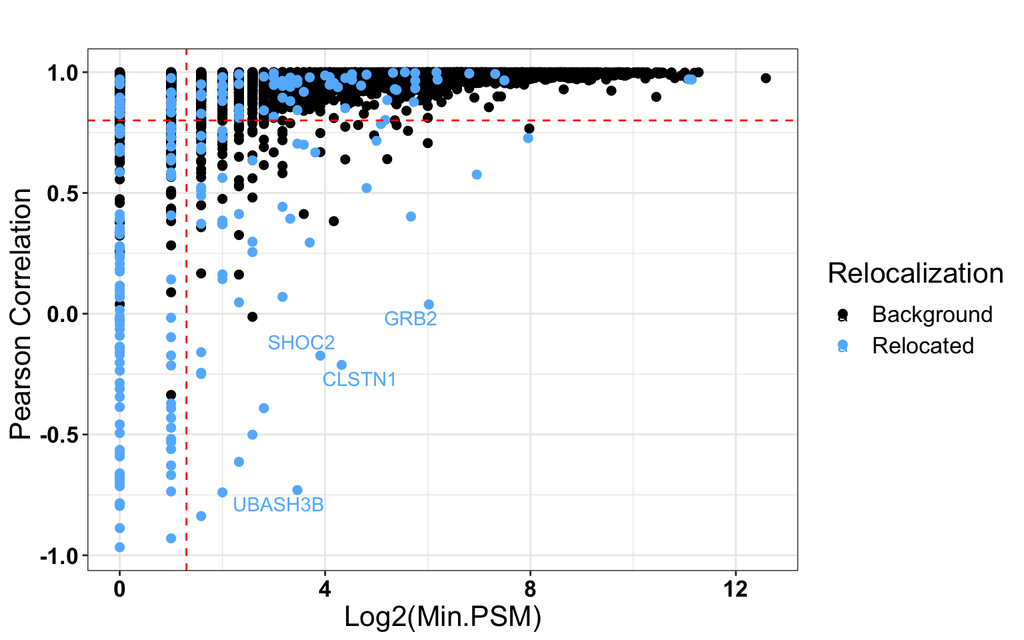

# 6 References

- Orre., et al. “SubCellBarCode: Proteome-wide Mapping of Protein Localization and Relocalization.” Molecular Cell (2019): 73(1):166-182.e7.